# Analiza czynników wpływających na ryzyko udaru mózgu

Zuzanna Wielgosz, Adam Skrzyński

2024-01-25

### Opis projektu

Analiza czynników wpływających na ryzyko udaru mózgu ma na celu integrację nauki i edukacji w obszarze zdrowia. Poprzez wykorzystanie danych zbioru “Stroke Prediction Dataset”, projekt skupia się na identyfikacji czynników ryzyka udaru, tworzeniu modelu predykcyjnego oraz edukacji na temat objawów, prewencji i szybkiego reagowania. Analiza danych, wizualizacje i przekazanie informacji o udarze mają wspólnie stanowić narzędzie wspierające świadomość zdrowotną i promocję zdrowego stylu życia.

### Wybrany zbiór danych

Wybranym do analizy zbiorem danych jest zbiór o nazwie Stroke prediction dataset.

Adres: https://www.kaggle.com/datasets/fedesoriano/stroke-prediction-dataset?resource=download

Stroke prediction dataset analizuje dane osobowe oraz zdrowotne dla ponad 5000 pacjentów. Główna zmienna modelowana to stroke, ma ona dwie klasy: pacjent przeszedł zawał lub nie.

### Ekstrakacja danych

Dane zostały wczytane z pliku csv wykorzysując funkcję read.csv z dodatkowymi atrybutami: - header = TRUE, ponieważ zbiór danych zawiera nagłówki - stringsAsFactors=TRUE, w celu zapisywania wartości tekstowych w postaci zmiennych kategorycznych

```r
stroke <- read.csv("https://storage.googleapis.com/kagglesdsdata/datasets/1120859/1882037/healthcare-dataset-stroke-data.csv?X-Goog-Algorithm=GOOG4-RSA-SHA256&X-Goog-Credential=gcp-kaggle-com%40kaggle-161607.iam.gserviceaccount.com%2F20240123%2Fauto%2Fstorage%2Fgoog4_request&X-Goog-Date=20240123T214754Z&X-Goog-Expires=259200&X-Goog-SignedHeaders=host&X-Goog-Signature=321f55d69f988d50edbb380008c0c2d1a504a91d45ed14229637bcd6721c…", header=TRUE, stringsAsFactors=TRUE)

head(stroke)
```

```
##      id gender age hypertension heart_disease ever_married     work_type
## 1  9046   Male  67            0             1          Yes       Private
## 2 51676 Female  61            0             0          Yes Self-employed
## 3 31112   Male  80            0             1          Yes       Private
## 4 60182 Female  49            0             0          Yes       Private
## 5  1665 Female  79            1             0          Yes Self-employed
## 6 56669   Male  81            0             0          Yes       Private
##   Residence_type avg_glucose_level  bmi  smoking_status stroke
## 1          Urban            228.69 36.6 formerly smoked      1
## 2          Rural            202.21  N/A    never smoked      1
## 3          Rural            105.92 32.5    never smoked      1
## 4          Urban            171.23 34.4          smokes      1
## 5          Rural            174.12   24    never smoked      1
## 6          Urban            186.21   29 formerly smoked      1
```

Analizując tabelę, można zauważyć że zawiera ona 11 różnych zmiennych (pierwszą kolumną jest id pacjenta, które nie jest potrzebne do analizy zbioru danych - nie wnosi do analizy żadnych przydatnych informacji).

Główną zmienną modelowaną jest “stroke”, ma ona dwie klasy: pacjent przeszedł udar (1) lub nie (0).

### Statystyki analizowanych danych

```r
library(ggplot2)
library(vioplot)
```

[output not shown]

```r
library(dplyr)
```

[output not shown]

[output not shown]

```r
stroke <- stroke[,-1]

head(stroke)
```

```
##   gender age hypertension heart_disease ever_married     work_type
## 1   Male  67            0             1          Yes       Private
## 2 Female  61            0             0          Yes Self-employed
## 3   Male  80            0             1          Yes       Private
## 4 Female  49            0             0          Yes       Private
## 5 Female  79            1             0          Yes Self-employed
## 6   Male  81            0             0          Yes       Private
##   Residence_type avg_glucose_level  bmi  smoking_status stroke
## 1          Urban            228.69 36.6 formerly smoked      1
## 2          Rural            202.21  N/A    never smoked      1
## 3          Rural            105.92 32.5    never smoked      1
## 4          Urban            171.23 34.4          smokes      1
## 5          Rural            174.12   24    never smoked      1
## 6          Urban            186.21   29 formerly smoked      1
```

```r
nrow(stroke)
```

```
## [1] 5110
```

```r
ncol(stroke)
```

```
## [1] 11
```

```r
summary(stroke)
```

```
##     gender          age         hypertension     heart_disease     ever_married
##  Female:2994   Min.   : 0.08   Min.   :0.00000   Min.   :0.00000   No :1757
##  Male  :2115   1st Qu.:25.00   1st Qu.:0.00000   1st Qu.:0.00000   Yes:3353
##  Other :   1   Median :45.00   Median :0.00000   Median :0.00000
##                Mean   :43.23   Mean   :0.09746   Mean   :0.05401
##                3rd Qu.:61.00   3rd Qu.:0.00000   3rd Qu.:0.00000
##                Max.   :82.00   Max.   :1.00000   Max.   :1.00000
##
##          work_type    Residence_type avg_glucose_level      bmi
##  children     : 687   Rural:2514     Min.   : 55.12    N/A    : 201
##  Govt_job     : 657   Urban:2596     1st Qu.: 77.25    28.7   :  41
##  Never_worked :  22                  Median : 91.89    28.4   :  38
##  Private      :2925                  Mean   :106.15    26.1   :  37
##  Self-employed: 819                  3rd Qu.:114.09    26.7   :  37
##                                      Max.   :271.74    27.6   :  37
##                                                        (Other):4719
##          smoking_status     stroke
##  formerly smoked: 885   Min.   :0.00000
##  never smoked   :1892   1st Qu.:0.00000
##  smokes         : 789   Median :0.00000
##  Unknown        :1544   Mean   :0.04873
##                         3rd Qu.:0.00000
##                         Max.   :1.00000
##
```

```r
sapply(stroke, class)
```

```
##            gender               age      hypertension     heart_disease
##          "factor"         "numeric"         "integer"         "integer"
##      ever_married         work_type    Residence_type avg_glucose_level
##          "factor"          "factor"          "factor"         "numeric"
##               bmi    smoking_status            stroke
##          "factor"          "factor"         "integer"
```

Główna kolumna danych (**stroke**) jest typu integer, ponieważ zawiera jedynie dane 0-1. Należy je jednak traktować jako wartości kategoryczne, gdzie 0 oznacza “False”, a 1 oznacza “True”. Nie należy tych danych traktować jako danych liczbowych.

Podobna sytuacja występuje dla wartości **hypertension** oraz **heart_disease**, gdzie są dane 0-1 i oznaczają brak wystąpienia lub wystąpienie danego schorzenia.

Wartości **age**, **bmi** (wg wywołanej funkcji, dane są typu factor, jednak wynika to z zapisu danych brakujących, o których wspomniano w następnym punkcie) oraz **avg_glucose_level** są zmiennymi typu numeric, a pozostałe kolumny są danymi kategorycznymi, czyli factor.

### Brakujące dane

Przyglądając się powyższemu podsumowaniu zbioru danych, można zauważyć, że w kolumnie **bmi** znajdują się dane brakujące oznaczone jako “N/A” oraz w kolumnie **smoking**, oznaczone jako “Unknown”. Ilość takich danych dla poszczególnych kolumn wynosi odpowiednio 201 i 1544.

### Dane odstające

W pierwszym kroku zdecydowano się na przeanalizowanie wartości bmi. W tym celu, dane zostały przefiltrowane poprzez usunięcie wierszy z wartościami N/A, a następnie utworzeno listę, której można użyć do wykresu wiolinowego.

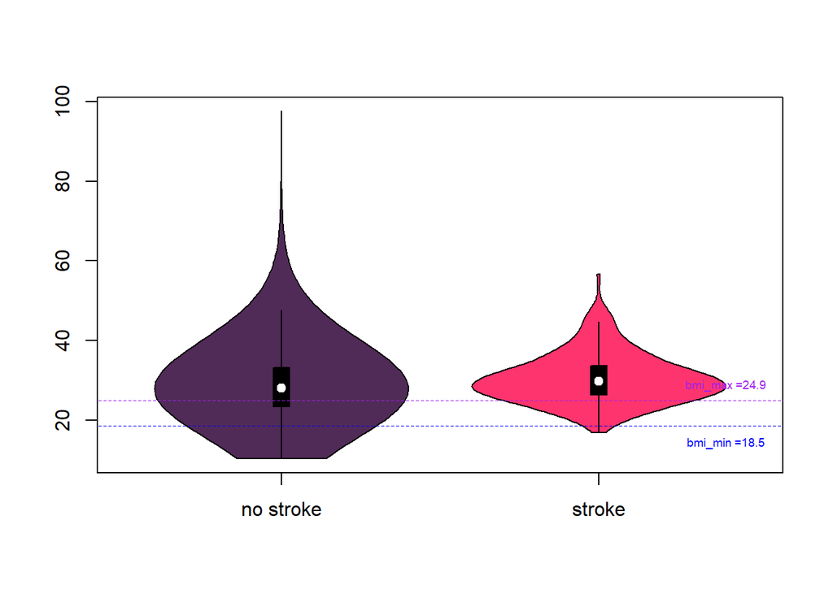

```r
stroke_clean_bmi <- stroke[!stroke$bmi == "N/A",]

stroke_clean_bmi$bmi  <- as.numeric(as.character(stroke_clean_bmi$bmi))

stroke_clean_bmi$stroke <- as.factor(stroke_clean_bmi$stroke)
  bmi_list <- lapply(levels(stroke_clean_bmi[["stroke"]]),
                       function(x) stroke_clean_bmi[ stroke_clean_bmi[, "stroke"] == x, "bmi"]
)

names(bmi_list) <- c("no stroke", "stroke")

library(vioplot)

vioplot(bmi_list, col=c("#512b58", "#fe346e"))

#minimalne normalne bmi
bmi_min <- 18.5
lines(c(0, 4), c(bmi_min, bmi_min), col="blue", lty=2, lwd=0.2)
text(2.4, bmi_min, paste("bmi_min =", bmi_min, sep=""), col="blue", pos=1, cex=0.6)

#maksymalne normalne bmi
bmi_max <- 24.9
lines(c(0, 4), c(bmi_max, bmi_max), col="purple", lty=2, lwd=0.2)
text(2.4, bmi_max, paste("bmi_max =", bmi_max, sep=""), col="purple", pos=3, cex=0.6)
```

Na wykresie zostały dodatkowo naniesione wartości minimalnego i maksymalnego bmi dla zdrowego człowieka.

## Analiza danych

### Wiek

Pierwszym krokiem analizy jest sprawdzenie zależności udaru lub jego braku od wieku pacjenta. Ten graficzny sposób prezentacji danych pozwoli na szybką identyfikację ewentualnych wzorców związanych z wiekiem a ryzykiem udarów, co może być istotne dla lekarzy i badaczy zajmujących się prewencją udarów oraz dostosowaniem strategii opieki zdrowotnej.

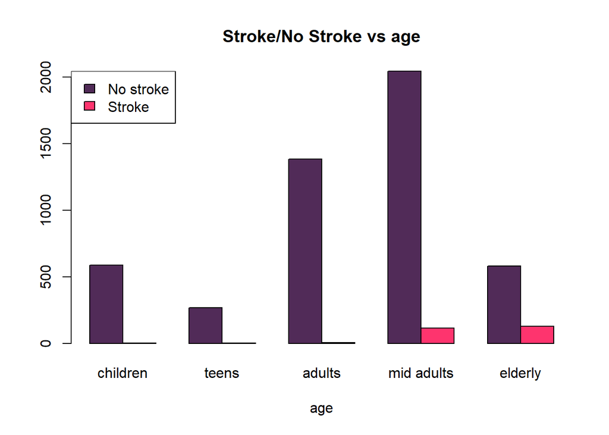

```r
# Tworzenie nowej kolumny age_category na podstawie wieku
stroke$age_category <- cut(stroke$age,
                           breaks = c(-Inf, 12, 17, 40, 70, Inf),
                           labels = c("children", "teens", "adults", "mid adults", "elderly"),
                           include.lowest = TRUE)


age_cat <- table(stroke$stroke, stroke$age_category)


barplot(age_cat,
main = "Stroke/No Stroke vs age",
xlab = "age",
col = c("#512b58","#fe346e"),
beside = TRUE
)
legend("topleft",
c("No stroke","Stroke"),
fill = c("#512b58","#fe346e")
)
```

[figure not shown]

```r
# Filtracja danych tylko dla stroke = 1
filtered_stroke_data <- subset(stroke, stroke == 1)

# Tabela przestawna dla stroke = 0 i kategorii wieku
age_cat <- table(filtered_stroke_data$stroke, filtered_stroke_data$age_category)

# Wykres słupkowy
barplot(age_cat,
        main = "No Stroke vs Age Category",
        xlab = "Age Category",
        col = c("#fe346e", "#512b58"),
        beside = TRUE
)

# Legenda
legend("topleft",
       c("No stroke"),
       fill = c("#512b58")
)
```

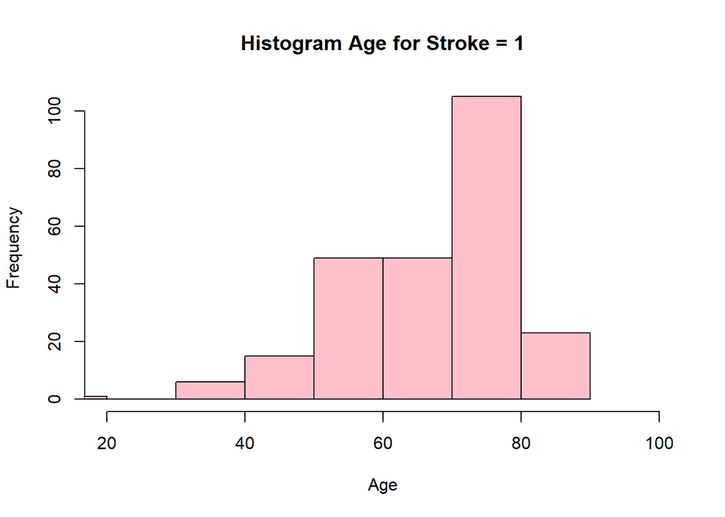

```r
hist(filtered_stroke_data$age,
     main = "Histogram Age for Stroke = 1",
     xlab = "Age",
     ylab = "Frequency",
     col = "pink",
     border = "black",
     xlim = c(20, 100),
)
```

```r
# Age-Stroke Distribution
ggplot(stroke, aes(x = age, fill = stroke)) +
  geom_density(alpha = 0.5) +
  labs(title = "Age-Stroke Distribution",
       x = "Age",
       y = "") +
scale_fill_manual(values = c("#512b58", "#fe346e"), labels = c("No Stroke", "Stroke")) +
  theme_minimal() +
  guides(fill = guide_legend(title = NULL)) +
  xlim(0, 100) +
  theme(axis.line.y = element_blank(),
        axis.text.y = element_blank())
```

**Warning** The following aesthetics were dropped during statistical transformation: fill

ℹ This can happen when ggplot fails to infer the correct grouping structure in

the data.

ℹ Did you forget to specify a `group` aesthetic or to convert a numerical

variable into a factor?

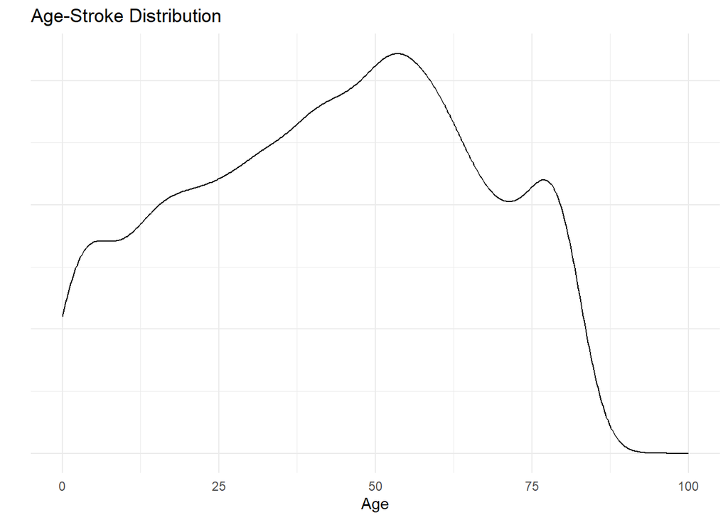

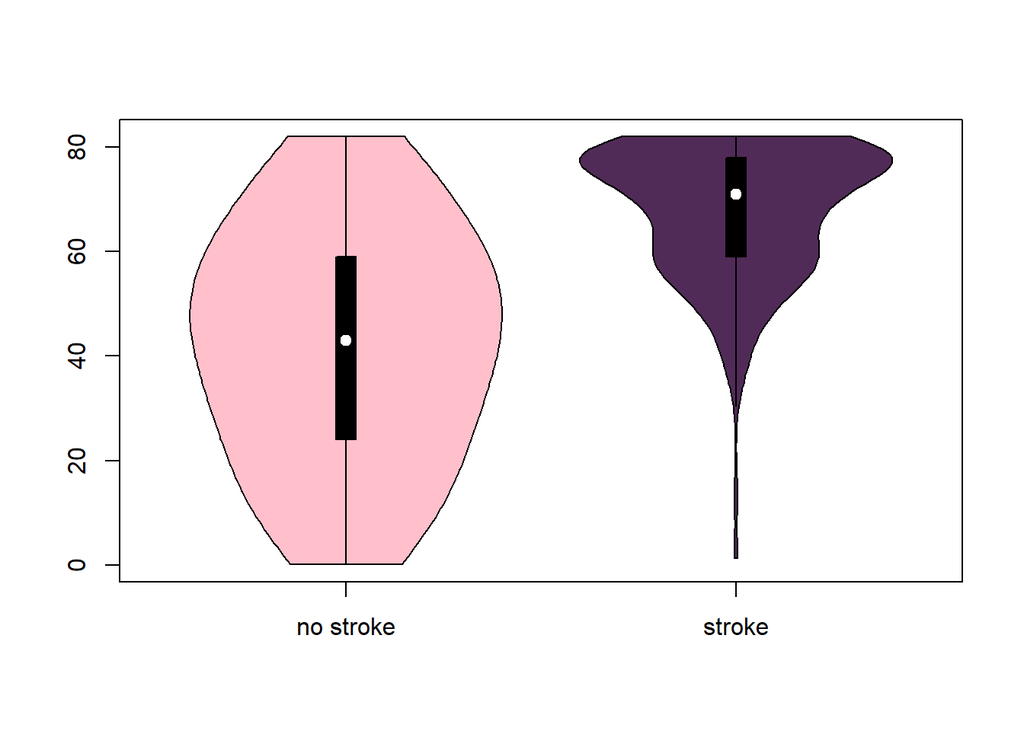

```r
#age
stroke$stroke <- as.factor(stroke$stroke)
age_list <- lapply(levels(stroke[["stroke"]]),
                       function(x) stroke[ stroke[, "stroke"] == x, "age"]
)
names(age_list) <- c("no stroke", "stroke")

vioplot(age_list, col=c("pink", "#512b58"))
```

Widać że w naszych danych zdecydowanie przeważają dane na temat pacjentów zdrowych, w tym przypadku po prostu takich którzy nie doświadczyli udaru Mid adults to przedział pomiędzy 40 a 70 lat

Analiza wykresu sugeruje, że ryzyko wystąpienia udaru mózgu (stroke) zwiększa się wraz z wiekiem. Widać, że udary w dużej mierze zaczęły pojawiać się mid adults do elderly. Całą tą obserwacje potwierdza histogram jak i 3 wykres, gdzie widzimy, że dużą część osób z udarem to osoby w wieku 60-90 lat.

Jest to zrozumiałem wpływa na to takie czynniki jak:

Różnice w stylu życia: Dorośli i starsi ludzie często prowadzą bardziej siedzący tryb życia niż dzieci i młodzież. Mniej aktywny tryb życia, brak regularnej aktywności fizycznej i złe nawyki żywieniowe mogą zwiększać ryzyko chorób sercowo-naczyniowych, w tym udaru.

Czynniki związane z wiekiem: Z wiekiem organizm ulega naturalnemu procesowi starzenia, co może prowadzić do akumulacji uszkodzeń komórkowych, miażdżycy i innych czynników zwiększających ryzyko udaru.

Czynniki genetyczne: Niektóre osoby mogą być genetycznie predysponowane do chorób sercowo-naczyniowych, co z kolei zwiększa ryzyko udaru. Geny mogą wpływać na czynniki takie jak poziom cholesterolu, ciśnienie krwi i skłonność do miażdżycy.

Choroby współistniejące: Starsze osoby często mają większą liczbę chorób współistniejących, takich jak cukrzyca, nadciśnienie, choroby serca itp. Te choroby zwiększają ryzyko udaru.

Stres: Dorośli i osoby starsze mogą częściej doświadczać stresu związanego z pracą, finansami, czy zdrowiem. Stres ten może wpływać na ogólne zdrowie serca i zwiększać ryzyko udaru.

### Glukoza

Wykres poziomu glukozy w zależności od obecności udaru lub jego braku u badanych pacjentów. Ten graficzny sposób prezentacji danych umożliwi zidentyfikowanie potencjalnych zależności między poziomem glukozy a ryzykiem udarów, co może być istotne dla lekarzy i badaczy zajmujących się zrozumieniem wpływu kontrolowania poziomu cukru na zdrowie naczyniowo-mózgowe pacjentów.

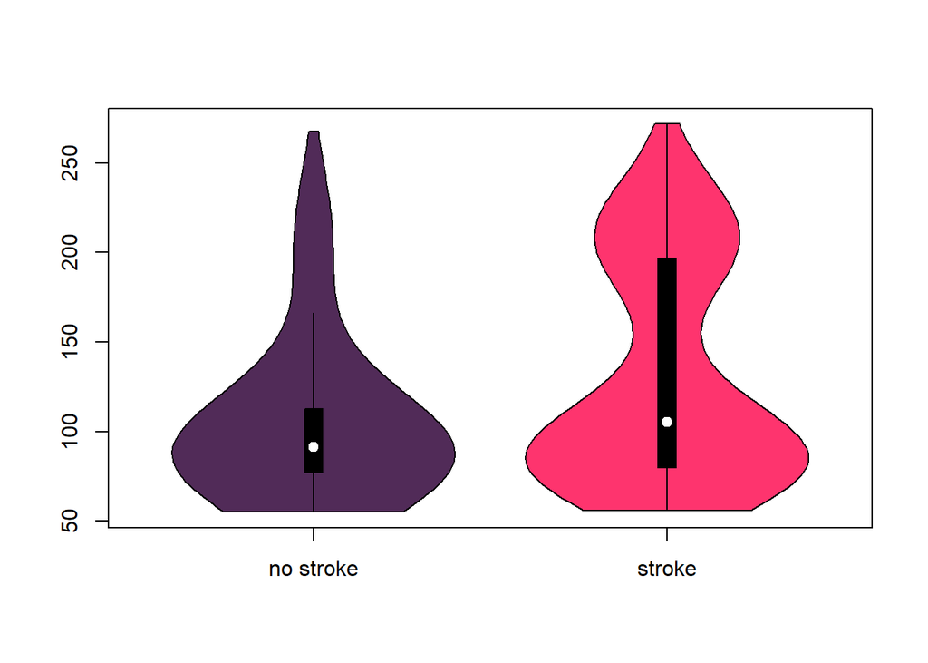

```r
#glucose
stroke$stroke <- as.factor(stroke$stroke)
glucose_list <- lapply(levels(stroke[["stroke"]]),
                       function(x) stroke[ stroke[, "stroke"] == x, "avg_glucose_level"]
)
names(glucose_list) <- c("no stroke", "stroke")

vioplot(glucose_list, col=c("#512b58", "#fe346e"))
```

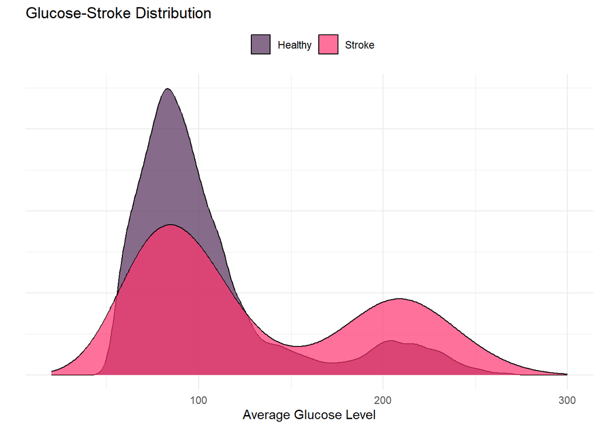

```r
# Glucose-Stroke Distribution
ggplot(stroke, aes(x = avg_glucose_level, fill = factor(stroke))) +
  geom_density(alpha = 0.7) +
  scale_fill_manual(values = c("#512b58", "#fe346e"), labels = c("Healthy", "Stroke")) +
  labs(title = "Glucose-Stroke Distribution",
       x = "Average Glucose Level",
       y = "") +
  theme_minimal() +
  xlim(20, 300)+
  theme(legend.position = "top") +
  guides(fill = guide_legend(title = NULL)) +
  theme(axis.line.y = element_blank(),
        axis.text.y = element_blank())
```

Cukrzyca i insulinooporność: Poziomy glukozy w zakresie 150-250 są często związane z cukrzycą lub insulinoopornością. Cukrzyca jest chorobą, która zwiększa ryzyko chorób sercowo-naczyniowych, w tym udaru. Podwyższony poziom glukozy może prowadzić do uszkodzeń naczyń krwionośnych i miażdżycy, zwiększając ryzyko udaru.

Problemy z regulacją glukozy po udarze: Osoby, które doświadczyły udaru, mogą mieć trudności z kontrolą poziomu glukozy. Zaburzenia metaboliczne po udarze mogą wpływać na poziom cukru we krwi, co z kolei zwiększa ryzyko powikłań sercowo-naczyniowych.

Związek między cukrzycą a udarem: Cukrzyca jest uznawana za istotny czynnik ryzyka udaru. Zaburzenia metaboliczne związane z cukrzycą mogą prowadzić do uszkodzeń naczyń krwionośnych, tworzenia się zakrzepów, a w konsekwencji do udaru mózgu.

Rola stanu zapalnego: Podwyższony poziom glukozy może wpływać na stan zapalny w organizmie, co również może przyczyniać się do uszkodzeń naczyń krwionośnych. Stan zapalny jest związany z rozwojem chorób sercowo-naczyniowych.

### Palenie papierosów

Poniżej przedstawiono wykres występowania udarów lub nie w zależności od tego czy pacjent palił wraz ze statystykami liczbowymi.

```r
# Smoking status
ggplot(stroke, aes(x = factor(smoking_status), fill = factor(stroke))) +
  geom_bar(position = 'dodge', stat = 'count', width = 0.7) +
  geom_text(aes(label = ..count..), stat = 'count', position = position_dodge(width = 0.7), vjust = -0.5) +  # Display count values on bars
  scale_fill_manual(values = c("#2c003e", "#fe346e"), labels = c("Healthy", "Stroke")) +
  scale_x_discrete(labels = c("Formaly Smoked", "Never Smoked","Smokes","Unknown")) +  # Change labels here
  labs(title = "Smoking Status And Risk",
       x = "Smoking Status",
       y = "") +
  theme_minimal() +
  theme(legend.position = "top") +
  guides(fill = guide_legend(title = NULL)) +
  ylim(c(0, 2000))  # Set your desired y-axis limits
```

**Warning** The dot-dot notation (`..count..`) was deprecated in ggplot2 3.4.0.

ℹ Please use `after_stat(count)` instead.

This warning is displayed once every 8 hours.

Call `lifecycle::last_lifecycle_warnings()` to see where this warning was

generated.

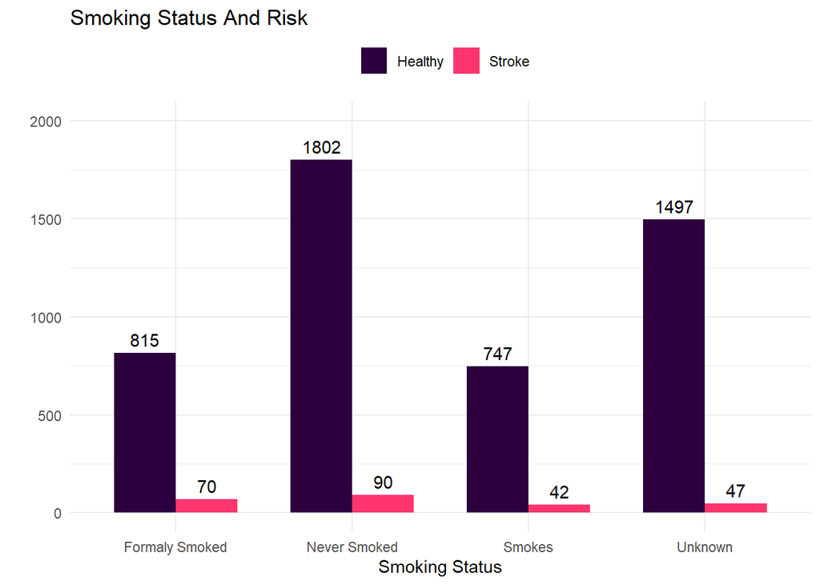

```r
smoking_status <- table(stroke$stroke, stroke$smoking_status)

smoking_status
```

```
##
##     formerly smoked never smoked smokes Unknown
##   0             815         1802    747    1497
##   1              70           90     42      47
```

Na powyższym wykresie można zauważyć, że ze zgromadzonych danych nie można wysnuć wniosku czy palenie w znaczącym stopniu wpływa na ryzyko udaru. Jednak według aktualnej wiedzy medycznej zdecydowanie jest to czynnik zdecydowanie istotny w przypadku udaru mózgu.

### BMI

Na poniższych wykresach znajduje się BMI badanych pacjentów w zależności od tego czy przechodzili udar mózgu czy nie.

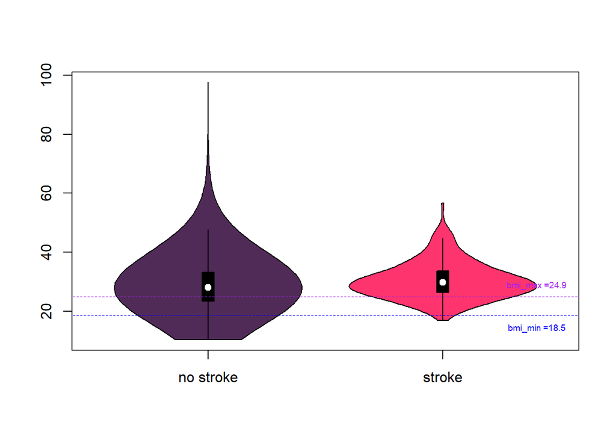

```r
stroke_clean_bmi <- stroke[!stroke$bmi == "N/A",]

stroke_clean_bmi$bmi  <- as.numeric(as.character(stroke_clean_bmi$bmi))

stroke_clean_bmi$stroke <- as.factor(stroke_clean_bmi$stroke)
  bmi_list <- lapply(levels(stroke_clean_bmi[["stroke"]]),
                       function(x) stroke_clean_bmi[ stroke_clean_bmi[, "stroke"] == x, "bmi"]
)

names(bmi_list) <- c("no stroke", "stroke")

library(vioplot)

vioplot(bmi_list, col=c("#512b58", "#fe346e"))

#minimalne normalne bmi
bmi_min <- 18.5
lines(c(0, 4), c(bmi_min, bmi_min), col="blue", lty=2, lwd=0.2)
text(2.4, bmi_min, paste("bmi_min =", bmi_min, sep=""), col="blue", pos=1, cex=0.6)

#maksymalne normalne bmi
bmi_max <- 24.9
lines(c(0, 4), c(bmi_max, bmi_max), col="purple", lty=2, lwd=0.2)
text(2.4, bmi_max, paste("bmi_max =", bmi_max, sep=""), col="purple", pos=3, cex=0.6)
```

```r
# Konwersja na tekst, a następnie na liczby
stroke$bmi <- as.numeric(as.character(stroke$bmi))
```

**Warning** pojawiły się wartości NA na skutek przekształcenia

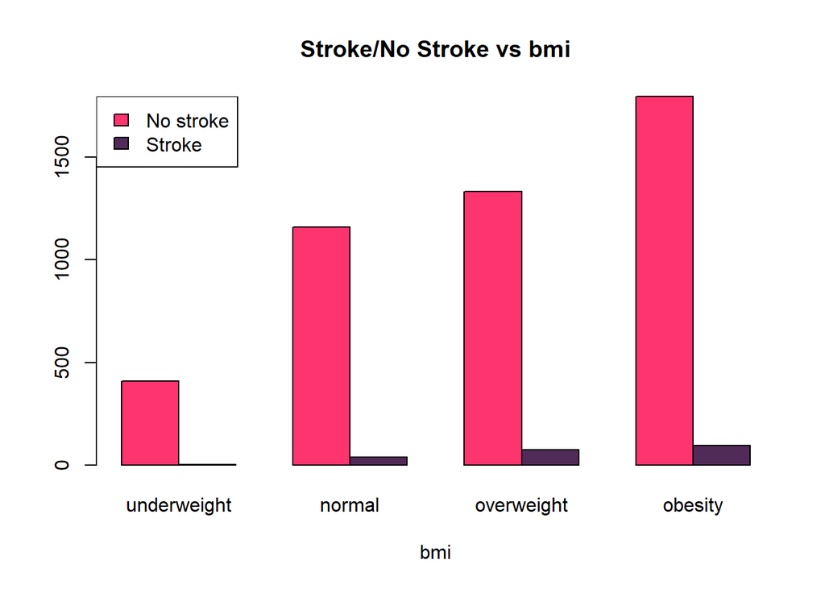

```r
stroke$bmi_category <- cut(stroke$bmi,
                           breaks = c(-Inf, 19, 25, 30, Inf),
                           labels = c("underweight", "normal", "overweight", "obesity"),
                           include.lowest = TRUE)

bmi_cat <- table(stroke$stroke, stroke$bmi_category)


barplot(bmi_cat,
main = "Stroke/No Stroke vs bmi",
xlab = "bmi",
col = c("#fe346e","#512b58"),
beside = TRUE
)
legend("topleft",
c("No stroke","Stroke"),
fill = c("#fe346e","#512b58")
)
```

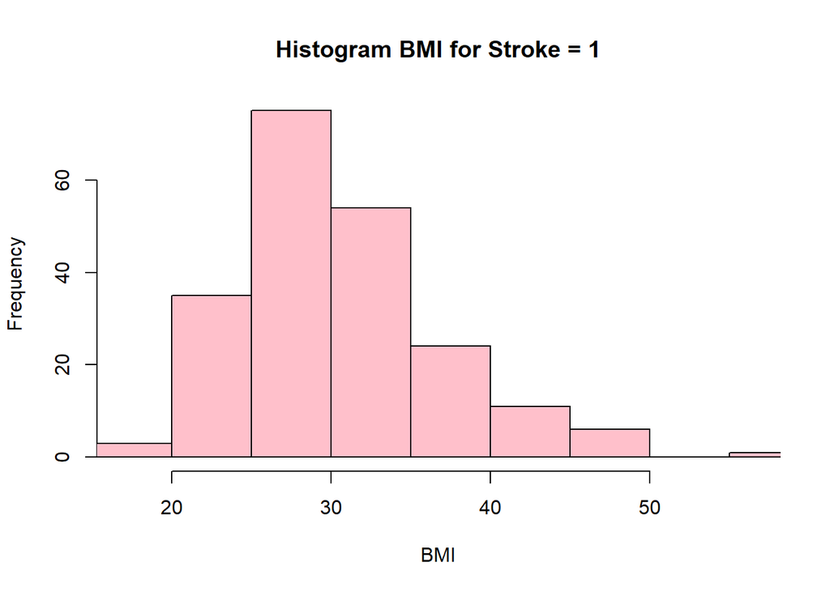

```r
# Usunięcie wierszy, w których bmi = NA
stroke <- na.omit(stroke)

# Filtracja danych tylko dla stroke = 1
filtered_stroke_data <- subset(stroke, stroke == 1)

# Filtracja danych tylko dla stroke = 1 i usuwanie brakujących danych w kolumnie bmi
filtered_stroke_data <- subset(stroke, stroke == 1 & !is.na(bmi))

# Wykres histogramu BMI
hist(filtered_stroke_data$bmi,
     main = "Histogram BMI for Stroke = 1",
     xlab = "BMI",
     ylab = "Frequency",
     col = "pink",
     border = "black",
     xlim = c(min(filtered_stroke_data$bmi), max(filtered_stroke_data$bmi)),
     breaks = "Sturges"  # Możesz dostosować metodę podziału przedziałów, np. "Sturges", "FD", "Scott"
)
```

```r
# BMI-Stroke Distribution

ggplot(stroke, aes(x = bmi, fill = factor(stroke))) +
  geom_density(alpha = 0.7) +
  scale_fill_manual(values = c("#512b58", "#fe346e"), labels = c("Healthy", "Stroke")) +
  labs(title = "BMI-Stroke Distribution",
       x = "Body Mass Index (BMI)",
       y = "") +
  theme_minimal() +
  xlim(0, 60) +
  theme(legend.position = "top") +
  guides(fill = guide_legend(title = NULL)) +
  theme(axis.line.y = element_blank(),
        axis.text.y = element_blank())
```

**Warning** Removed 13 rows containing non-finite values (`stat_density()`).

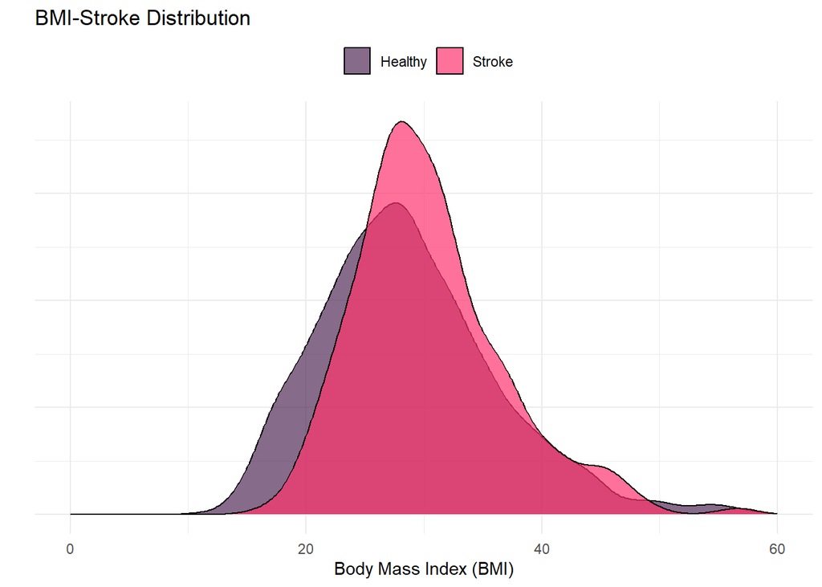

Otyłość a ryzyko udaru: Otyłość jest jednym z głównych czynników ryzyka chorób sercowo-naczyniowych, w tym udaru mózgu. Osoby z nadwagą i otyłe mają zazwyczaj podwyższoną presję krwi, zwiększone ryzyko cukrzycy typu 2, hiperlipidemię i stan zapalny, co może przyczynić się do powstawania zakrzepów i miażdżycy, prowadzących do udaru.

Nadwaga a ryzyko udaru: Nawet umiarkowane zwiększenie masy ciała, niewłaściwa dystrybucja tkanki tłuszczowej i brak aktywności fizycznej mogą przyczyniać się do podwyższonego ryzyka udaru.

Wpływ na czynniki ryzyka: Otyłość może wpływać na różne czynniki ryzyka, takie jak ciśnienie krwi, poziom cholesterolu, insulinooporność i stany zapalne, co z kolei wpływa na zdrowie układu sercowo-naczyniowego.

### Płeć

Poniżej znajduje się wykres na temat zależności udaru od płci na podstawie zgromadzonych danych.

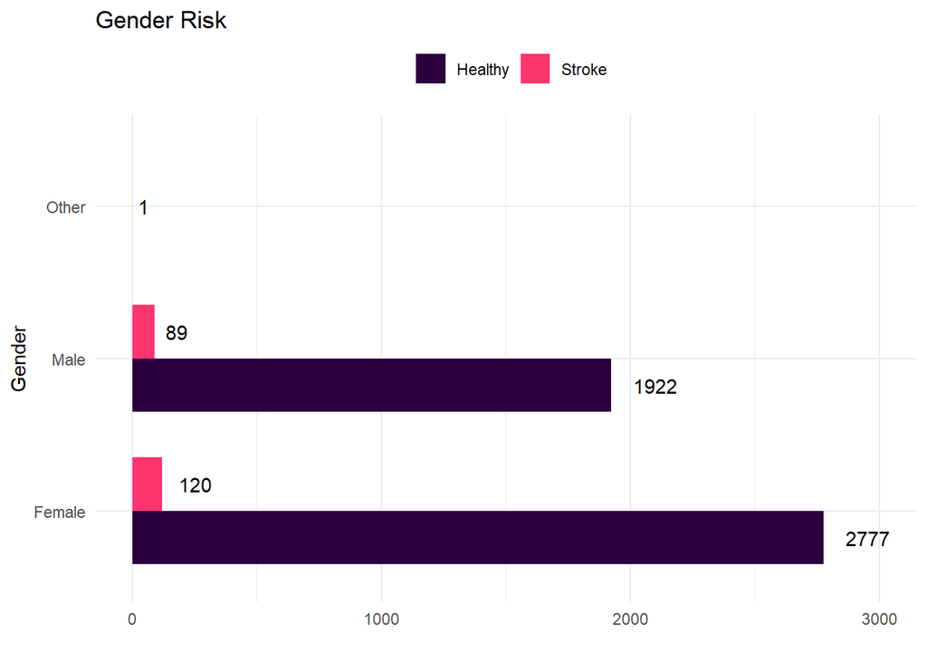

```r
# Gender Risk
ggplot(stroke, aes(y = factor(gender), fill = factor(stroke))) +
  geom_bar(position = 'dodge', stat = 'count', width = 0.7) +
  geom_text(aes(label = ..count..), stat = 'count', position = position_dodge(width = 0.7), hjust = -0.5) +  # Display count values on bars
  scale_fill_manual(values = c("#2c003e", "#fe346e"), labels = c("Healthy", "Stroke")) +
  labs(title = "Gender Risk",
       x = "",
       y = "Gender") +
  theme_minimal() +
  theme(legend.position = "top") +
  guides(fill = guide_legend(title = NULL)) +
  xlim(c(0, 3000))  # Set your desired x-axis limits
```

### Dodatkowe wykresy

#### Typ wykonywanej pracy

[figure not shown]

```r
# Employment Risk
ggplot(stroke, aes(x = factor(work_type), fill = factor(stroke))) +
  geom_bar(position = 'dodge', stat = 'count', width = 0.7) +
  geom_text(aes(label = ..count..), stat = 'count', position = position_dodge(width = 0.7), vjust = -0.5) +  # Display count values on bars
  scale_fill_manual(values = c("#2c003e", "#fe346e"), labels = c("Healthy", "Stroke")) +
  scale_x_discrete(labels = c("Private", "Self-Employed", "Children", "Gov-Job", "Never worked")) +  # Change labels here
  labs(title = "Employment Risk",
       x = "Work Type",
       y = "") +
  theme_minimal() +
  theme(legend.position = "top") +
  guides(fill = guide_legend(title = NULL)) +
  ylim(c(0, 4000))  # Set your desired y-axis limits
```

#### Stan cywilny

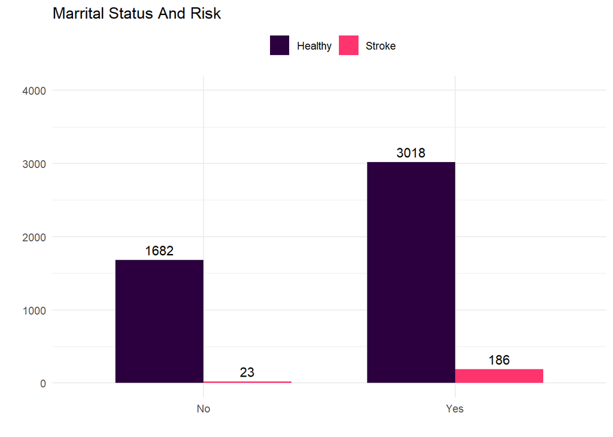

```r
# Marrital Status
ggplot(stroke, aes(x = factor(ever_married), fill = factor(stroke))) +
  geom_bar(position = 'dodge', stat = 'count', width = 0.7) +
  geom_text(aes(label = ..count..), stat = 'count', position = position_dodge(width = 0.7), vjust = -0.5) +  # Display count values on bars
  scale_fill_manual(values = c("#2c003e", "#fe346e"), labels = c("Healthy", "Stroke")) +
  labs(title = "Marrital Status And Risk",
       x = "",
       y = "") +
  theme_minimal() +
  theme(legend.position = "top") +
  guides(fill = guide_legend(title = NULL)) +
  ylim(c(0, 4000))  # Set your desired y-axis limits
```